# Tarea 6: SPARK

Tarea 6 de Métodos de Gran Escala

## Set up

Para realizar esta tarea descargamos la imagen de Docker jupyter/pyspark-notebook que levanta un spark con python y te permite usar jupyter notebooks desde el browser de tu computadora local. Recomiendo esto para correr spark en un ambiente local sin tener que pelearse mucho con las configuraciones, más referencias en https://medium.com/@suci/running-pyspark-on-jupyter-notebook-with-docker-602b18ac4494

En la terminal vemos esto:

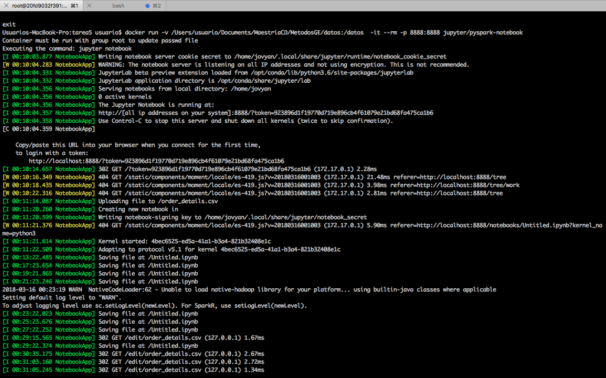

Mientras que en el browser vemos esto:

[figure not shown]

## Preguntas y queries utilizados

Ejercicio 1. Con la base de datos de northwind que se encuentran en el dropbox:

1. ¿Cuántos “jefes” hay en la tabla empleados? ¿Cuáles son estos jefes: número de empleado, nombre, apellido, título, fecha de nacimiento, fecha en que iniciaron en la empresa, ciudad y país?

3. ¿Cuál es el delta de tiempo más grande entre una orden y otra?

Ejercicio 2. Con los archivos de vuelos, aeropuertos y aerolíneas que están en el dropbox

1. ¿Qué aerolíneas (nombres) llegan al aeropuerto “Honolulu International Airport”?
2. ¿En qué horario (hora del día, no importan los minutos) hay salidas del aeropuerto de San Francisco (“SFO”) a “Honolulu International Airport”?
3. ¿Qué día de la semana y en qué aerolínea nos conviene viajar a “Honolulu International Airport” para tener el menor retraso posible?
4. ¿Cuál es el aeropuerto con mayor tráfico de entrada?

5. ¿Cuál es la aerolínea con mayor retraso de salida por día de la semana?

6. ¿Cuál es la tercer aerolínea con menor retraso de salida los lunes (day of week = 2)?

7. ¿Cuál es el aeropuerto origen que llega a la mayor cantidad de aeropuertos destino diferentes?